# Sixth Week: Linear Models

House price prediction

Yasmin Sarcheshmehpour 94109827

2018-04-12 23:16:53

> با توجه به داده های قیمت منازل لطفا با سوالات زیر پاسخ دهید.

```r
library(readr)
library(magrittr)

house = read.csv("house/train.csv")
```

۱. ماتریس همبستگی متغیرهای مختلف را به دست آورده و سپس رسم نمایید. اعداد به دست آمده را با آزمون فرض معناداری همبستگی بسنجید و سپس ده متغیری که همبستگی بالاتری با قیمت دارند را مشخص نمایید.

```r
library("dplyr")
```

```r
library(corrplot)
house %>% select_if(is.numeric) -> cor_data
cor_data %>% cor() %>% round(2) -> cor_mat
cor_mat[, c('SalePrice')] -> price_data
sort(price_data[!is.na(price_data)])
```

```
##  KitchenAbvGr EnclosedPorch    MSSubClass   OverallCond  LowQualFinSF
##         -0.14         -0.13         -0.08         -0.08         -0.03
##        YrSold            Id  BsmtHalfBath       MiscVal    BsmtFinSF2
##         -0.03         -0.02         -0.02         -0.02         -0.01
##    X3SsnPorch        MoSold      PoolArea   ScreenPorch  BedroomAbvGr
##          0.04          0.05          0.09          0.11          0.17
##     BsmtUnfSF  BsmtFullBath       LotArea      HalfBath     X2ndFlrSF
##          0.21          0.23          0.26          0.28          0.32
##    WoodDeckSF   OpenPorchSF    BsmtFinSF1    Fireplaces  YearRemodAdd
##          0.32          0.32          0.39          0.47          0.51
##     YearBuilt  TotRmsAbvGrd      FullBath   TotalBsmtSF     X1stFlrSF
##          0.52          0.53          0.56          0.61          0.61
##    GarageArea    GarageCars     GrLivArea   OverallQual     SalePrice
##          0.62          0.64          0.71          0.79          1.00
```

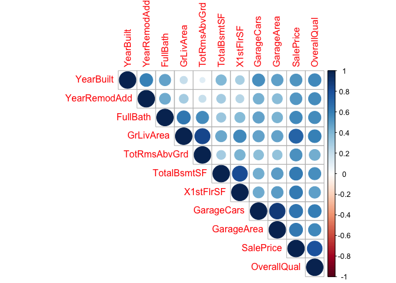

```r
names(head(sort(price_data[!is.na(price_data)], decreasing = TRUE), 11)) -> top_10
subset(house, select=top_10) -> selected_data
selected_data %>% cor() %>% round(2) -> cor_mat
corrplot(cor_mat, type="upper", order="hclust", sig.level = 0.01, insig ="blank")
```

```r
cor.test(selected_data$SalePrice, selected_data$OverallQual)
```

```
##
##  Pearson's product-moment correlation
##
## data:  selected_data$SalePrice and selected_data$OverallQual
## t = 49.364, df = 1458, p-value < 2.2e-16
## alternative hypothesis: true correlation is not equal to 0
## 95 percent confidence interval:
##  0.7709644 0.8094376
## sample estimates:
##       cor
## 0.7909816
```

```r
cor.test(selected_data$SalePrice, selected_data$GrLivArea)
```

```
##
##  Pearson's product-moment correlation
##
## data:  selected_data$SalePrice and selected_data$GrLivArea
## t = 38.348, df = 1458, p-value < 2.2e-16
## alternative hypothesis: true correlation is not equal to 0
## 95 percent confidence interval:
##  0.6821200 0.7332695
## sample estimates:
##       cor
## 0.7086245
```

```r
cor.test(selected_data$SalePrice, selected_data$GarageCars)
```

```
##
##  Pearson's product-moment correlation
##
## data:  selected_data$SalePrice and selected_data$GarageCars
## t = 31.839, df = 1458, p-value < 2.2e-16
## alternative hypothesis: true correlation is not equal to 0
## 95 percent confidence interval:
##  0.6091192 0.6697086
## sample estimates:
##       cor
## 0.6404092
```

```r
cor.test(selected_data$SalePrice, selected_data$GarageArea)
```

```
##
##  Pearson's product-moment correlation
##
## data:  selected_data$SalePrice and selected_data$GarageArea
## t = 30.446, df = 1458, p-value < 2.2e-16
## alternative hypothesis: true correlation is not equal to 0
## 95 percent confidence interval:
##  0.5910324 0.6538222
## sample estimates:
##       cor
## 0.6234314
```

```r
cor.test(selected_data$SalePrice, selected_data$TotalBsmtSF)
```

```
##
##  Pearson's product-moment correlation
##
## data:  selected_data$SalePrice and selected_data$TotalBsmtSF
## t = 29.671, df = 1458, p-value < 2.2e-16
## alternative hypothesis: true correlation is not equal to 0
## 95 percent confidence interval:
##  0.5805529 0.6445923
## sample estimates:
##       cor
## 0.6135806
```

```r
cor.test(selected_data$SalePrice, selected_data$X1stFlrSF)
```

```
##
##  Pearson's product-moment correlation
##
## data:  selected_data$SalePrice and selected_data$X1stFlrSF
## t = 29.078, df = 1458, p-value < 2.2e-16
## alternative hypothesis: true correlation is not equal to 0
## 95 percent confidence interval:
##  0.5723391 0.6373448
## sample estimates:
##       cor
## 0.6058522
```

```r
cor.test(selected_data$SalePrice, selected_data$FullBath)
```

```
##
##  Pearson's product-moment correlation
##
## data:  selected_data$SalePrice and selected_data$FullBath
## t = 25.854, df = 1458, p-value < 2.2e-16
## alternative hypothesis: true correlation is not equal to 0
## 95 percent confidence interval:
##  0.5244463 0.5948560
## sample estimates:
##       cor
## 0.5606638
```

```r
cor.test(selected_data$SalePrice, selected_data$TotRmsAbvGrd)
```

```
##
##  Pearson's product-moment correlation
##
## data:  selected_data$SalePrice and selected_data$TotRmsAbvGrd
## t = 24.099, df = 1458, p-value < 2.2e-16
## alternative hypothesis: true correlation is not equal to 0
## 95 percent confidence interval:
##  0.4960020 0.5694337
## sample estimates:
##       cor
## 0.5337232
```

```r
cor.test(selected_data$SalePrice, selected_data$YearBuilt)
```

```
##
##  Pearson's product-moment correlation
##
## data:  selected_data$SalePrice and selected_data$YearBuilt
## t = 23.424, df = 1458, p-value < 2.2e-16
## alternative hypothesis: true correlation is not equal to 0
## 95 percent confidence interval:
##  0.4845947 0.5591987
## sample estimates:
##       cor
## 0.5228973
```

```r
cor.test(selected_data$SalePrice, selected_data$YearRemodAdd)
```

```
##
##  Pearson's product-moment correlation
##
## data:  selected_data$SalePrice and selected_data$YearRemodAdd
## t = 22.466, df = 1458, p-value < 2.2e-16
## alternative hypothesis: true correlation is not equal to 0
## 95 percent confidence interval:
##  0.4679732 0.5442445
## sample estimates:
##      cor
## 0.507101
```

فرض صفر: کورلیشن صفر است

در همه ی موارد چون پی-ولیو عدد بسیار کوچکی است فرض صفر رد میشود

۲. در یک تصویر نمودار پراکنش دو به دو ده متغیر بدست آمده به همراه قیمت را رسم نمایید و هم خطی بودن متغیرها را بررسی کنید

```r
library("car")
```

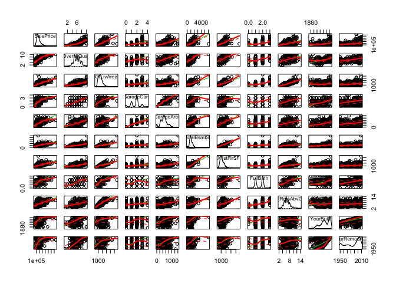

```r
scatterplotMatrix(selected_data)
```

مواردی که نقاط سیاه نزدیک به خط قرمز هستند، هم خطی میباشند

مانند saleprice & yearbuilt

۳. یک مدل خطی بر اساس ده متغیر برای پیش بینی قیمت برازش دهید. و سپس خلاصه نتایج مدل را به دست آورید.

```r
linearMod = lm(SalePrice ~ OverallQual+GrLivArea+GarageCars+GarageArea+TotalBsmtSF+X1stFlrSF+FullBath+TotRmsAbvGrd+YearBuilt+YearRemodAdd, data = selected_data)
summary(linearMod)
```

```
##
## Call:
## lm(formula = SalePrice ~ OverallQual + GrLivArea + GarageCars +
##     GarageArea + TotalBsmtSF + X1stFlrSF + FullBath + TotRmsAbvGrd +
##     YearBuilt + YearRemodAdd, data = selected_data)
##
## Residuals:
##     Min      1Q  Median      3Q     Max
## -489958  -19316   -1948   16020  290558
##
## Coefficients:
##                Estimate Std. Error t value Pr(>|t|)
## (Intercept)  -1.186e+06  1.291e+05  -9.187  < 2e-16 ***
## OverallQual   1.960e+04  1.190e+03  16.472  < 2e-16 ***
## GrLivArea     5.130e+01  4.233e+00  12.119  < 2e-16 ***
## GarageCars    1.042e+04  3.044e+03   3.422 0.000639 ***
## GarageArea    1.495e+01  1.031e+01   1.450 0.147384
## TotalBsmtSF   1.986e+01  4.295e+00   4.625 4.09e-06 ***
## X1stFlrSF     1.417e+01  4.930e+00   2.875 0.004097 **
## FullBath     -6.791e+03  2.682e+03  -2.532 0.011457 *
## TotRmsAbvGrd  3.310e+01  1.119e+03   0.030 0.976404
## YearBuilt     2.682e+02  5.035e+01   5.328 1.15e-07 ***
## YearRemodAdd  2.965e+02  6.363e+01   4.659 3.47e-06 ***
## ---
## Signif. codes:  0 '***' 0.001 '**' 0.01 '*' 0.05 '.' 0.1 ' ' 1
##
## Residual standard error: 37920 on 1449 degrees of freedom
## Multiple R-squared:  0.7737, Adjusted R-squared:  0.7721
## F-statistic: 495.4 on 10 and 1449 DF,  p-value: < 2.2e-16
```

۴. نمودار قیمت واقعی و قیمت پیش بینی را رسم نمایید و خوب بودن مدل را ارزیابی کنید.

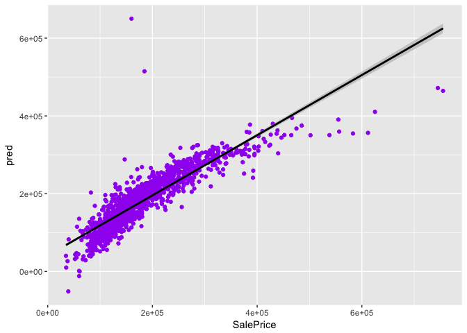

```r
library(ggplot2)
selected_data %>% mutate(pred = predict(linearMod, selected_data, type = "response")) -> selected_data
#selected_data %>% select(SalePrice, pred)
ggplot(selected_data, aes(x = SalePrice, y = pred)) + geom_point(color="purple") + geom_smooth(method="lm", formula=y~x, colour = "black")
```

چون خط رسم شده در نمودار به خط x=y نزدیک است مدل نسبتا خوبی است

۵. مقدار R-squared مدل را به دست آورید. آیا بر اساس این کمیت مدل به خوبی به داده ها برازش داده شده است؟ کمیت F-statistic را در خلاصه مدل تفسیر نمایید.

```r
summary(linearMod)
```

```
##
## Call:
## lm(formula = SalePrice ~ OverallQual + GrLivArea + GarageCars +
##     GarageArea + TotalBsmtSF + X1stFlrSF + FullBath + TotRmsAbvGrd +
##     YearBuilt + YearRemodAdd, data = selected_data)
##
## Residuals:
##     Min      1Q  Median      3Q     Max
## -489958  -19316   -1948   16020  290558
##
## Coefficients:
##                Estimate Std. Error t value Pr(>|t|)
## (Intercept)  -1.186e+06  1.291e+05  -9.187  < 2e-16 ***
## OverallQual   1.960e+04  1.190e+03  16.472  < 2e-16 ***
## GrLivArea     5.130e+01  4.233e+00  12.119  < 2e-16 ***
## GarageCars    1.042e+04  3.044e+03   3.422 0.000639 ***
## GarageArea    1.495e+01  1.031e+01   1.450 0.147384
## TotalBsmtSF   1.986e+01  4.295e+00   4.625 4.09e-06 ***
## X1stFlrSF     1.417e+01  4.930e+00   2.875 0.004097 **
## FullBath     -6.791e+03  2.682e+03  -2.532 0.011457 *
## TotRmsAbvGrd  3.310e+01  1.119e+03   0.030 0.976404
## YearBuilt     2.682e+02  5.035e+01   5.328 1.15e-07 ***
## YearRemodAdd  2.965e+02  6.363e+01   4.659 3.47e-06 ***
## ---
## Signif. codes:  0 '***' 0.001 '**' 0.01 '*' 0.05 '.' 0.1 ' ' 1
##
## Residual standard error: 37920 on 1449 degrees of freedom
## Multiple R-squared:  0.7737, Adjusted R-squared:  0.7721
## F-statistic: 495.4 on 10 and 1449 DF,  p-value: < 2.2e-16
```

چون r-squared=0.7 و به ۱ نزدیک است مدل نسبتا خوبی داریم

همچنین برای f-statistic چون پی-ولیو عدد بسیار کوچکی است نشان میدهد که مدل خوبی داریم

۶. بر اساس p-value سطح معناداری ضرایب تصمیم بگیرید که چه متغیرهایی در مدل سازی استفاده شود. بر اساس متغیرهای جدید دوباره مدل سازی کنید و نتایج رو گزارش دهید.

آن هایی را باید انتخاب کنیم که پی-ولیو آنها کم است.

```r
summary(linearMod)
```

```
##
## Call:
## lm(formula = SalePrice ~ OverallQual + GrLivArea + GarageCars +
##     GarageArea + TotalBsmtSF + X1stFlrSF + FullBath + TotRmsAbvGrd +
##     YearBuilt + YearRemodAdd, data = selected_data)
##
## Residuals:
##     Min      1Q  Median      3Q     Max
## -489958  -19316   -1948   16020  290558
##
## Coefficients:
##                Estimate Std. Error t value Pr(>|t|)
## (Intercept)  -1.186e+06  1.291e+05  -9.187  < 2e-16 ***
## OverallQual   1.960e+04  1.190e+03  16.472  < 2e-16 ***
## GrLivArea     5.130e+01  4.233e+00  12.119  < 2e-16 ***
## GarageCars    1.042e+04  3.044e+03   3.422 0.000639 ***
## GarageArea    1.495e+01  1.031e+01   1.450 0.147384
## TotalBsmtSF   1.986e+01  4.295e+00   4.625 4.09e-06 ***
## X1stFlrSF     1.417e+01  4.930e+00   2.875 0.004097 **
## FullBath     -6.791e+03  2.682e+03  -2.532 0.011457 *
## TotRmsAbvGrd  3.310e+01  1.119e+03   0.030 0.976404
## YearBuilt     2.682e+02  5.035e+01   5.328 1.15e-07 ***
## YearRemodAdd  2.965e+02  6.363e+01   4.659 3.47e-06 ***
## ---
## Signif. codes:  0 '***' 0.001 '**' 0.01 '*' 0.05 '.' 0.1 ' ' 1
##
## Residual standard error: 37920 on 1449 degrees of freedom
## Multiple R-squared:  0.7737, Adjusted R-squared:  0.7721
## F-statistic: 495.4 on 10 and 1449 DF,  p-value: < 2.2e-16
```

```r
selected_data %>% select(SalePrice, OverallQual, GrLivArea, GarageCars, TotalBsmtSF, YearBuilt, YearRemodAdd) -> better_data
betterMod = lm(SalePrice ~ OverallQual+GrLivArea+GarageCars+TotalBsmtSF+YearBuilt+YearRemodAdd, data = better_data)
summary(betterMod)
```

```
##
## Call:
## lm(formula = SalePrice ~ OverallQual + GrLivArea + GarageCars +
##     TotalBsmtSF + YearBuilt + YearRemodAdd, data = better_data)
##
## Residuals:
##     Min      1Q  Median      3Q     Max
## -477106  -19737   -2015   16452  290098
##
## Coefficients:
##                Estimate Std. Error t value Pr(>|t|)
## (Intercept)  -1.053e+06  1.218e+05  -8.650  < 2e-16 ***
## OverallQual   1.912e+04  1.186e+03  16.123  < 2e-16 ***
## GrLivArea     5.036e+01  2.551e+00  19.743  < 2e-16 ***
## GarageCars    1.439e+04  1.813e+03   7.939 4.03e-15 ***
## TotalBsmtSF   3.086e+01  2.811e+00  10.979  < 2e-16 ***
## YearBuilt     2.211e+02  4.802e+01   4.605 4.49e-06 ***
## YearRemodAdd  2.757e+02  6.353e+01   4.340 1.52e-05 ***
## ---
## Signif. codes:  0 '***' 0.001 '**' 0.01 '*' 0.05 '.' 0.1 ' ' 1
##
## Residual standard error: 38100 on 1453 degrees of freedom
## Multiple R-squared:  0.7709, Adjusted R-squared:   0.77
## F-statistic:   815 on 6 and 1453 DF,  p-value: < 2.2e-16
```

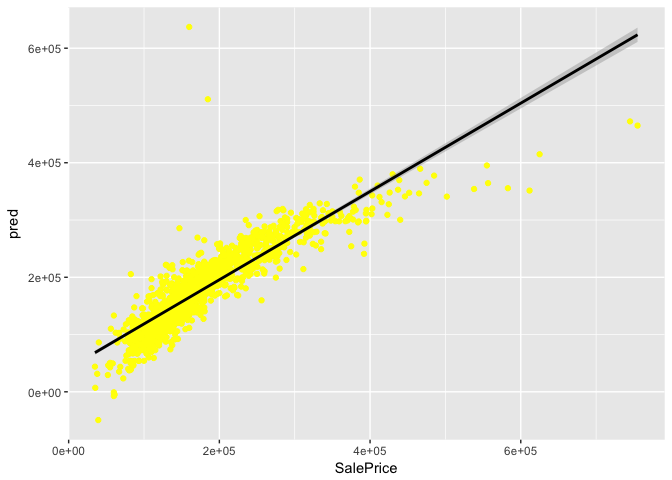

```r
better_data %>% mutate(pred = predict(betterMod, better_data, type = "response"))  %>%
ggplot(aes(x = SalePrice, y = pred)) + geom_point(color="yellow") + geom_smooth(method="lm", formula=y~x, colour = "black")
```

۷. مدل خود را بر اساس باقی مانده نقص یابی کنید. سه محک normality, independance, Constant Variance را در نقص یابی خود در نظر بگیرید.

normality

فرض صفر: همانند توزیع نرمال است

چون پی-ولیو عدد بسیار کوچکی است پس فرض صفر رد میشود و در نمودار رسم شده هم مشاهده میشود

```r
library(fBasics)
jarqueberaTest(betterMod$resid)
```

```
##
## Title:
##  Jarque - Bera Normalality Test
##
## Test Results:
##   STATISTIC:
##     X-squared: 48686.1212
##   P VALUE:
##     Asymptotic p Value: < 2.2e-16
##
## Description:
##  Thu Apr 12 23:17:03 2018 by user:
```

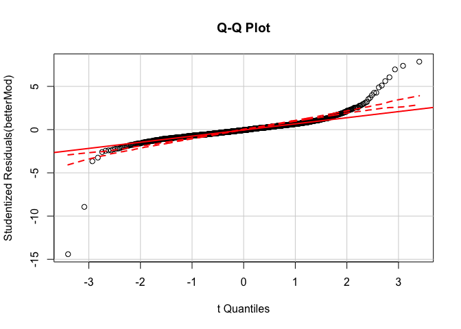

```r
car::qqPlot(betterMod, id.method="identify",simulate = TRUE, main="Q-Q Plot")
```

independance

فرض صفر: فیچر ها مستقل اند

چون پی-ولیو بیشتر از ۰.۰۵ است پس فرض صفر قبول میشود

```r
library(lmtest) #dwtest
dwtest(betterMod)
```

```
##
##  Durbin-Watson test
##
## data:  betterMod
## DW = 1.9731, p-value = 0.3031
## alternative hypothesis: true autocorrelation is greater than 0
```

Constant Variance

چون خط کشیده شده صاف نیست پس واریانس ثابت نمیباشد

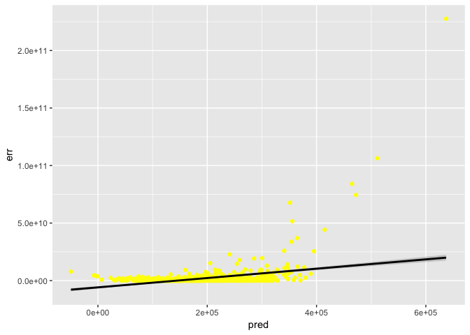

```r
better_data %>% mutate(pred = predict(betterMod, better_data, type = "response"))  %>%
  mutate(err=(pred-SalePrice)*(pred-SalePrice)) %>%
ggplot(aes(x = pred, y = err)) + geom_point(color="yellow") + geom_smooth(method="lm", formula=y~x, colour = "black")
```

۸. داده ها را به پنج قسمت تقسیم کنید. بر اساس چهار قسمت مدل خطی را بسازید و صحت مدل را برای یک قسمت باقی مانده را تست کنید. خطای پیش بینی شما چقدر است؟

```r
sample_size = floor(0.8*nrow(better_data))
train_index = sample(seq_len(nrow(better_data)), sample_size, replace = FALSE, prob = NULL)
train_data = better_data[train_index,]
test_data = better_data[-train_index,]
trainMod = lm(SalePrice ~ OverallQual+GrLivArea+GarageCars+TotalBsmtSF+YearBuilt+YearRemodAdd, data = train_data)
summary(trainMod)
```

```
##
## Call:
## lm(formula = SalePrice ~ OverallQual + GrLivArea + GarageCars +
##     TotalBsmtSF + YearBuilt + YearRemodAdd, data = train_data)
##
## Residuals:
##     Min      1Q  Median      3Q     Max
## -483991  -19749   -2266   16461  284752
##
## Coefficients:
##                Estimate Std. Error t value Pr(>|t|)
## (Intercept)  -1.105e+06  1.340e+05  -8.241 4.56e-16 ***
## OverallQual   1.869e+04  1.303e+03  14.341  < 2e-16 ***
## GrLivArea     5.369e+01  2.759e+00  19.458  < 2e-16 ***
## GarageCars    1.330e+04  1.929e+03   6.896 8.76e-12 ***
## TotalBsmtSF   2.968e+01  3.053e+00   9.720  < 2e-16 ***
## YearBuilt     2.466e+02  5.195e+01   4.748 2.32e-06 ***
## YearRemodAdd  2.767e+02  6.970e+01   3.971 7.61e-05 ***
## ---
## Signif. codes:  0 '***' 0.001 '**' 0.01 '*' 0.05 '.' 0.1 ' ' 1
##
## Residual standard error: 37450 on 1161 degrees of freedom
## Multiple R-squared:  0.7779, Adjusted R-squared:  0.7768
## F-statistic: 677.7 on 6 and 1161 DF,  p-value: < 2.2e-16
```

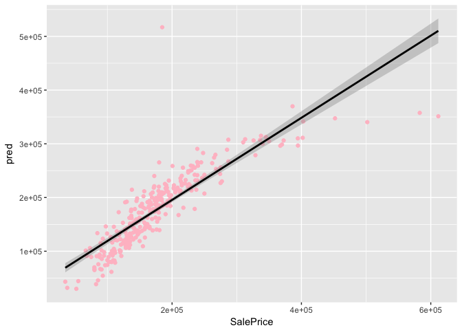

```r
test_data %>% mutate(pred = predict(trainMod, test_data, type = "response"))  %>%
ggplot(aes(x = SalePrice, y = pred)) + geom_point(color="pink") + geom_smooth(method="lm", formula=y~x, colour = "black")
```

۹. آیا قیمت ربط غیر خطی با یکی از ده متغیر استفاده شده دارد؟ بر اساس دستاوردهای خود مدل را بهتر نمایید.

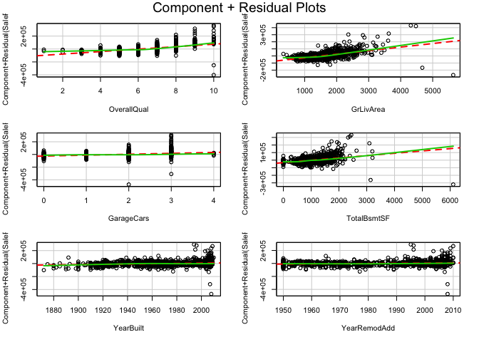

```r
crPlots(betterMod)
```

همانطور که مشاهده میشود قیمت با YearRenodAdd و YearBuilt رابطه ی خطی دارد و با بقیه ندارد

```r
last_data = train_data
last_data %>% mutate(g1 = log(GrLivArea)) -> last_data
last_data %>% mutate(g2 = log(log(GrLivArea))) -> last_data
last_data %>% mutate(t1 = log(TotalBsmtSF+0.0001)) -> last_data
last_data %>% mutate(t2 = log(log(TotalBsmtSF+0.0001)+0.0001)) -> last_data
lastMod = lm(SalePrice ~ OverallQual+GarageCars+YearRemodAdd+YearBuilt+g1+g2+t1+t2, data = last_data)
summary(lastMod)
```

```
##
## Call:
## lm(formula = SalePrice ~ OverallQual + GarageCars + YearRemodAdd +
##     YearBuilt + g1 + g2 + t1 + t2, data = last_data)
##
## Residuals:
##     Min      1Q  Median      3Q     Max
## -471299  -18174    -738   15592  252833
##
## Coefficients:
##                Estimate Std. Error t value Pr(>|t|)
## (Intercept)   8.754e+06  7.204e+05  12.151  < 2e-16 ***
## OverallQual   1.954e+04  1.277e+03  15.299  < 2e-16 ***
## GarageCars    1.304e+04  1.905e+03   6.845 1.25e-11 ***
## YearRemodAdd  3.159e+02  6.805e+01   4.641 3.87e-06 ***
## YearBuilt     2.236e+02  5.079e+01   4.402 1.17e-05 ***
## g1            1.435e+06  9.868e+04  14.547  < 2e-16 ***
## g2           -9.894e+06  7.154e+05 -13.829  < 2e-16 ***
## t1            1.863e+05  5.493e+04   3.392 0.000718 ***
## t2           -9.782e+05  3.727e+05  -2.624 0.008802 **
## ---
## Signif. codes:  0 '***' 0.001 '**' 0.01 '*' 0.05 '.' 0.1 ' ' 1
##
## Residual standard error: 35820 on 1129 degrees of freedom
##   (30 observations deleted due to missingness)
## Multiple R-squared:  0.7966, Adjusted R-squared:  0.7952
## F-statistic: 552.8 on 8 and 1129 DF,  p-value: < 2.2e-16
```

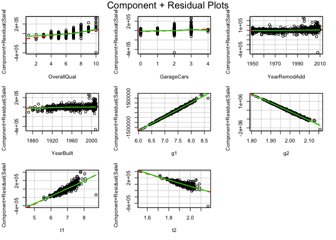

```r
crPlots(lastMod)
```

۱۰. بر اساس مدل نهایی به دست آمده نتایج پیش بینی خود را بر روی test.csv به دست آورید و در سایت kaggle در مسابقه House Prices: Advanced Regression Techniques بارگذاری نمایید. سپس لینک رتبه و عدد آن را ضمیمه تمرین کنید.

score = 0.23112

```r
kaggle = read.csv("house/test.csv")
kaggle %>%
  mutate(g1 = log(GrLivArea))%>%
  mutate(g2 = log(log(GrLivArea))) %>%
  mutate(t1 = log(TotalBsmtSF+0.0001)) %>%
  mutate(t2 = log(log(TotalBsmtSF+0.0001)+0.0001)) -> kaggle
kaggle %>% mutate(SalePrice = predict(lastMod, kaggle, type = "response")) %>% select(Id, SalePrice) -> kaggle
filtered_data = na.omit(kaggle)
mean_price = mean(filtered_data$SalePrice)
kaggle[is.na(kaggle)] <- mean_price
write.csv(kaggle,'pred.csv', row.names = FALSE)
```

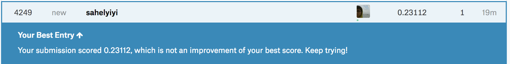

Kaggle score.